# Pokemon!

Jaeyoon Han

2016-03-28

## Cluster and Visualize Pokemons

본 내용은 `highcharter` 패키지의 제작자인 [Joshua Kunst](http://jkunst.com)의 블로그의 포스트를 더 자세하게 재작성한 것임을 밝힌다.

```r
library(dplyr)
```

기존 데이터는 포켓몬 이름이 영어이므로, 한글로 바꾸기 위해서는 새로운 데이터가 필요하다. [포켓몬 목록 위키피디아 페이지](https://ko.wikipedia.org/wiki/%ED%8F%AC%EC%BC%93%EB%AA%AC_%EB%AA%A9%EB%A1%9D)에 있는 표를 스크래핑해서 이름은 따로 사용하도록 한다. 또한 전체 포켓몬이 아닌 2세대(251마리)만 필요하므로 기존 데이터에서 251마리만 사용하도록 한다.

```r
library(rvest)
url <- "https://ko.wikipedia.org/wiki/%ED%8F%AC%EC%BC%93%EB%AA%AC_%EB%AA%A9%EB%A1%9D"
wiki_poke <- read_html(url)

first_gen <- wiki_poke %>%
        html_nodes(xpath='//*[@id="mw-content-text"]/table[1]') %>%
        html_table() %>%
        .[[1]]

second_gen <- wiki_poke %>%
        html_nodes(xpath='//*[@id="mw-content-text"]/table[2]') %>%
        html_table() %>%
        .[[1]]

poke_list_ko <- c(first_gen[, 2], second_gen[, 2])
```

혹시라도 니드런♀, 니드런♂ 항목에서 기호가 문제가 된다면 다음과 같이 하면 된다.

```r
poke_list_ko[grepl("니드런", poke_list_ko)] <- c("니드런(암)", "니드런(수)")
```

이제 포켓몬 데이터를 불러오도록 한다. 여러 데이터를 조인(Join)으로 합쳐서 다룰 예정이다.

```r
library(dplyr)
library(tidyr)
library(stringr)
library(purrr) # map_df()
library(readr) # read_csv() // 한글 포함된 파일에선 문제 발생
path <- function(x) paste0("https://raw.githubusercontent.com/phalt/pokeapi/master/data/v2/csv/", x)

pkmn <- read_csv(path("pokemon.csv")) %>%
        select(-(order : is_default)) %>%
        rename(pokemon = identifier)

stat <- read_csv(path("stats.csv")) %>%
        rename(stat_id = id) %>%
        right_join(read_csv(path("pokemon_stats.csv")),
                   by = "stat_id") %>%
        mutate(identifier = str_replace(identifier, "-", "_")) %>%
        select(pokemon_id, identifier, base_stat) %>%
        spread(identifier, base_stat) %>%
        rename(id = pokemon_id)

type <- read_csv(path("types.csv")) %>%
        rename(type_id = id) %>%
        right_join(read_csv(path("pokemon_types.csv")),
                   by = "type_id") %>%
        select(pokemon_id, identifier, slot) %>%
        mutate(slot = paste0("type_", slot)) %>%
        spread(slot, identifier) %>%
        rename(id = pokemon_id)

egg <- read_csv(path("egg_groups.csv")) %>%
        rename(egg_group_id = id) %>%
        right_join(read_csv(path("pokemon_egg_groups.csv")),
                   by = "egg_group_id") %>%
        group_by(species_id) %>%
        mutate(ranking = row_number(),
               ranking = paste0("egg_group_", ranking)) %>%
        select(species_id, ranking, identifier) %>%
        spread(ranking, identifier)

img <- "https://github.com/phalt/pokeapi/tree/master/data/Pokemon_XY_Sprites" %>%
        read_html() %>%
        html_nodes("tr.js-navigation-item > .content > .css-truncate a") %>%
        map_df(function(x){
                url <- x %>% html_attr("href")
                data_frame(
                        id = str_extract(basename(url), "\\d+"),
                        url_image = basename(url)
                )
        }) %>%
        mutate(id = as.numeric(id))

url_bulbapedia_list <- "http://bulbapedia.bulbagarden.net/wiki/List_of_Pok%C3%A9mon_by_base_stats_(Generation_VI-present)"

id <- url_bulbapedia_list %>%
        read_html(encoding = "UTF-8") %>%
        html_node("table.sortable") %>%
        html_table() %>%
        .[[1]] %>%
        as.numeric()
url_icon <-  url_bulbapedia_list %>%
        read_html() %>%
        html_nodes("table.sortable img") %>%
        html_attr("src")

icon <- data_frame(id, url_icon) %>%
        filter(!is.na(id)) %>%
        distinct(id)

color <- map_df(na.omit(unique(c(type$type_1, type$type_2))), function(t){
        # t <- "bug"
        col <- "http://pokemon-uranium.wikia.com/wiki/Template:%s_color" %>%
                sprintf(t) %>%
                read_html() %>%
                html_nodes("span > b") %>%
                html_text()
        data_frame(type = t, color = paste0("#", col))
})

colorf <- expand.grid(color_1 = color$color, color_2 = color$color,
                      stringsAsFactors = FALSE) %>%
        group_by(color_1, color_2) %>%
        do({
                n = 100; p = 0.27
                data_frame(color_f = colorRampPalette(c(.$color_1, .$color_2))(n)[round(n*p)])
                # colorRampPalette(a, b)(n)[m]는 a 색깔부터 b 색깔까지의
                # 그라디언트 색 n 개를 생성해서 m 번째 색을 선택하는 함수
                # 이상해씨와 같이 풀 타입과 독 타입을 같이 가지고 있는 경우,
                # 위 함수를 써서 포켓몬을 나타내는 색을 지정한다.
        })

pokemon <- pkmn %>%
        left_join(type, by = "id") %>%
        left_join(stat, by = "id") %>%
        left_join(color %>% rename(type_1 = type, color_1 = color), by = "type_1") %>%
        left_join(color %>% rename(type_2 = type, color_2 = color), by = "type_2") %>%
        left_join(colorf, by =  c("color_1", "color_2")) %>%
        left_join(egg, by = "species_id") %>%
        left_join(img, by = "id") %>%
        left_join(icon, by = "id") %>%
        .[1:251, ]

# 포켓몬 이름을 한글로 바꿔준다.
pokemon["pokemon"] <- poke_list_ko
```

이상해씨와 같이 여러 타입을 동시에 가지고 있는 경우 `color_f` 칼럼에 데이터가 존재하지만, 파이리와 같이 단일 타입인 경우 `color_f` 칼럼값이 `NA`다. 이 경우, `color_f`값을 `color_1`값으로 가질 수 있도록 하자.

```r
pokemon <- pokemon %>%
        mutate(color_f = ifelse(is.na(color_f), color_1, color_f)) %>%
        filter(!is.na(url_image))

head(pokemon)
```

| id | pokemon | species_id | height | weight | base_experience | type_1 | type_2 | attack | defense | hp | special_attack | special_defense | speed | color_1 | color_2 | color_f | egg_group_1 | egg_group_2 | url_image | url_icon |
| --- | --- | --- | --- | --- | --- | --- | --- | --- | --- | --- | --- | --- | --- | --- | --- | --- | --- | --- | --- | --- |
| 1 | 이상해씨 | 1 | 7 | 69 | 64 | grass | poison | 49 | 49 | 45 | 65 | 65 | 45 | #78C850 | #A040A0 | #82A465 | monster | plant | 1.png | http://cdn.bulbagarden.net/upload/e/ec/001MS.png |
| 2 | 이상해풀 | 2 | 10 | 130 | 142 | grass | poison | 62 | 63 | 60 | 80 | 80 | 60 | #78C850 | #A040A0 | #82A465 | monster | plant | 2.png | http://cdn.bulbagarden.net/upload/6/6b/002MS.png |
| 3 | 이상해꽃 | 3 | 20 | 1000 | 236 | grass | poison | 82 | 83 | 80 | 100 | 100 | 80 | #78C850 | #A040A0 | #82A465 | monster | plant | 3.png | http://cdn.bulbagarden.net/upload/d/df/003MS.png |
| 4 | 파이리 | 4 | 6 | 85 | 62 | fire | NA | 52 | 43 | 39 | 60 | 50 | 65 | #F08030 | NA | #F08030 | monster | dragon | 4.png | http://cdn.bulbagarden.net/upload/b/bb/004MS.png |
| 5 | 리자드 | 5 | 11 | 190 | 142 | fire | NA | 64 | 58 | 58 | 80 | 65 | 80 | #F08030 | NA | #F08030 | monster | dragon | 5.png | http://cdn.bulbagarden.net/upload/d/dc/005MS.png |
| 6 | 리자몽 | 6 | 17 | 905 | 240 | fire | flying | 84 | 78 | 78 | 109 | 85 | 100 | #F08030 | #A890F0 | #DD8462 | monster | dragon | 6.png | http://cdn.bulbagarden.net/upload/0/01/006MS.png |

막대 그래프를 이용해 각 타입을 기준으로 2세대 포켓몬을 구분하고자 한다. 악타입과 강철타입은 2세대에서 새로 생겼고, 페어리타입은 6세대에서 추가되었다. 본 데이터는 최신판을 기준으로 한다. 이 때, 시각화는 `highchart()`를 활용한다.

```r
library(Hmisc)
```

```r
library(highcharter)

pokemon$type_1 <- capitalize(pokemon$type_1)
pokemon$type_2 <- capitalize(pokemon$type_2)

dstype <- pokemon %>%
        count(type_1, color_1) %>%
        ungroup() %>%
        arrange(desc(n)) %>%
        rename(name = type_1,
               color = color_1,
               y = n) %>%
        select(y, name, color) %>%
        list.parse3()

type_bar <- highchart() %>%
        hc_xAxis(categories = unlist(pluck(dstype, i = 2))) %>%
        hc_yAxis(title = NULL) %>%
        hc_add_series(data = dstype, type = "bar", showInLegend = FALSE,
                      name = "Number of Species")

type_bar
```

[interactive chart not shown]

막대 그래프를 이용한 결과도 충분히 미려하지만, 단일 타입만 나타낼 수 있다는 한계가 있었다. 이번에는 트리맵을 이용해서 보다 다양한 타입 경우의 수를 나타내도록 하자.

```r
set.seed(3514)
library(treemap)

tm <- pokemon %>%
        mutate(type_2 = ifelse(is.na(type_2), paste("Only", type_1), type_2),
               type_1 = type_1) %>%
        group_by(type_1, type_2) %>%
        summarise(n = n()) %>%
        ungroup() %>%
        treemap(index = c("type_1", "type_2"),
                vSize = "n", vColor = "type_1")
```

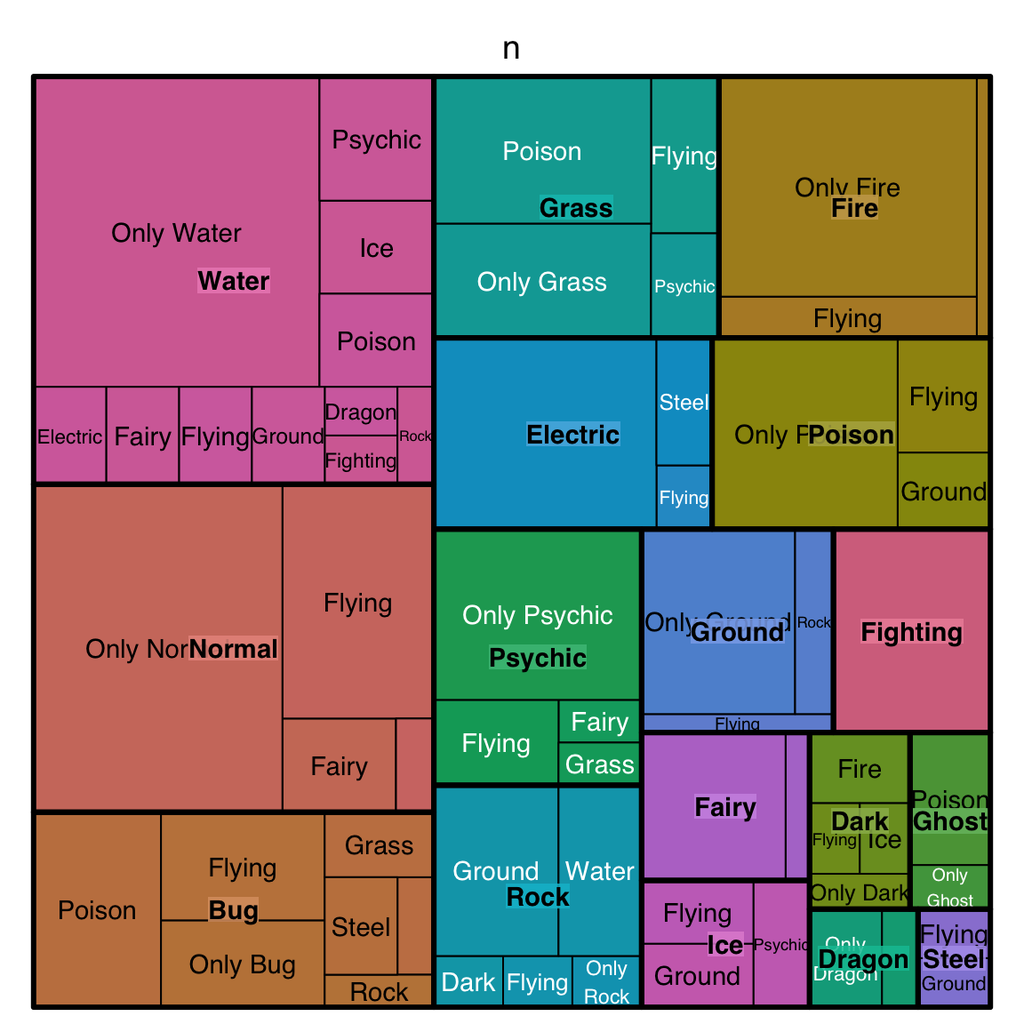

결과가 마음에 들지 않는다. 각 타입의 느낌을 한 눈에 받을 수도 없고, 전체적으로 깔끔하지 못하다는 인상을 받았다. 이번에는 `highchart()`를 이용해 트리맵을 그려보도록 하자.